# TUGAS TPG

Zanira Husna G1401231097

2025-11-05

```r
library(factoextra)
library(cluster)
library(clusterCrit)
library(dplyr)
library(ggplot2)
library(tidyr)
library(scales)
library(RColorBrewer)
```

# Data

Data yang digunakan merupakan data bawaan R, yaitu data ‘state.x77’. Data berisi berbagai indikator ekonomi, sosial, dan kesehatan dari 50 negara bagian Amerika Serikat.

```r
# Muat dataset
data(state.x77)
# Ubah ke data frame
data_state <- as.data.frame(state.x77)

# Lihat struktur data
str(data_state)
```

```
## 'data.frame':    50 obs. of  8 variables:
##  $ Population: num  3615 365 2212 2110 21198 ...
##  $ Income    : num  3624 6315 4530 3378 5114 ...
##  $ Illiteracy: num  2.1 1.5 1.8 1.9 1.1 0.7 1.1 0.9 1.3 2 ...
##  $ Life Exp  : num  69 69.3 70.5 70.7 71.7 ...
##  $ Murder    : num  15.1 11.3 7.8 10.1 10.3 6.8 3.1 6.2 10.7 13.9 ...
##  $ HS Grad   : num  41.3 66.7 58.1 39.9 62.6 63.9 56 54.6 52.6 40.6 ...
##  $ Frost     : num  20 152 15 65 20 166 139 103 11 60 ...
##  $ Area      : num  50708 566432 113417 51945 156361 ...
```

```r
head(data_state)
```

```
##            Population Income Illiteracy Life Exp Murder HS Grad Frost   Area
## Alabama          3615   3624        2.1    69.05   15.1    41.3    20  50708
## Alaska            365   6315        1.5    69.31   11.3    66.7   152 566432
## Arizona          2212   4530        1.8    70.55    7.8    58.1    15 113417
## Arkansas         2110   3378        1.9    70.66   10.1    39.9    65  51945
## California      21198   5114        1.1    71.71   10.3    62.6    20 156361
## Colorado         2541   4884        0.7    72.06    6.8    63.9   166 103766
```

## Standarisasi skala pada data

```r
# Standarisasi data
data_scaled <- scale(data_state)

# Cek hasil standarisasi
head(data_scaled)
```

```
##            Population     Income Illiteracy   Life Exp     Murder    HS Grad
## Alabama    -0.1414316 -1.3211387   1.525758 -1.3621937  2.0918101 -1.4619293
## Alaska     -0.8693980  3.0582456   0.541398 -1.1685098  1.0624293  1.6828035
## Arizona    -0.4556891  0.1533029   1.033578 -0.2447866  0.1143154  0.6180514
## Arkansas   -0.4785360 -1.7214837   1.197638 -0.1628435  0.7373617 -1.6352611
## California  3.7969790  1.1037155  -0.114842  0.6193415  0.7915396  1.1751891
## Colorado   -0.3819965  0.7294092  -0.771082  0.8800698 -0.1565742  1.3361400
##                 Frost       Area
## Alabama    -1.6248292 -0.2347183
## Alaska      0.9145676  5.8093497
## Arizona    -1.7210185  0.5002047
## Arkansas   -0.7591257 -0.2202212
## California -1.6248292  1.0034903
## Colorado    1.1838976  0.3870991
```

# Clustering

Penentuan nilai k

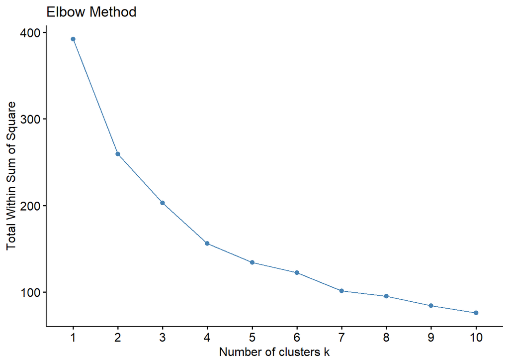

```r
fviz_nbclust(data_scaled, kmeans, method = "wss") +
labs(title = "Elbow Method")
```

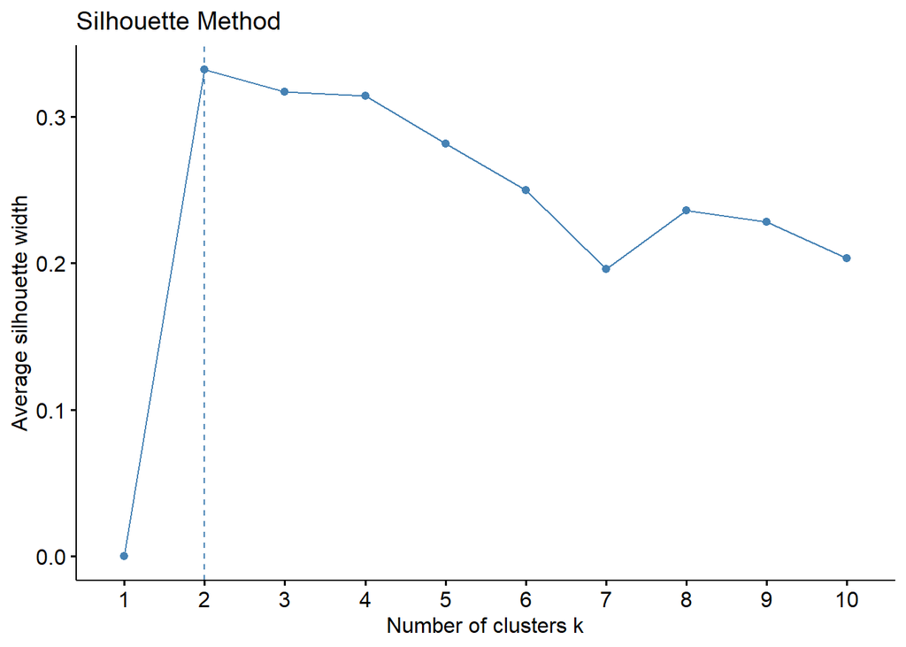

```r
fviz_nbclust(data_scaled, kmeans, method = "silhouette") +
labs(title = "Silhouette Method")
```

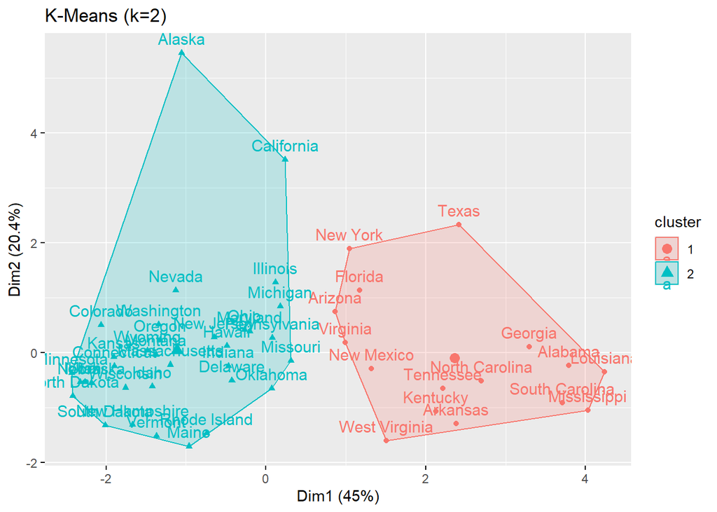

```r
par(mfrow = c(1, 2))
# k = 2
km2 <- kmeans(scale(state.x77), centers = 2, nstart = 25)
fviz_cluster(km2, data = scale(state.x77), main = "K-Means (k=2)")
```

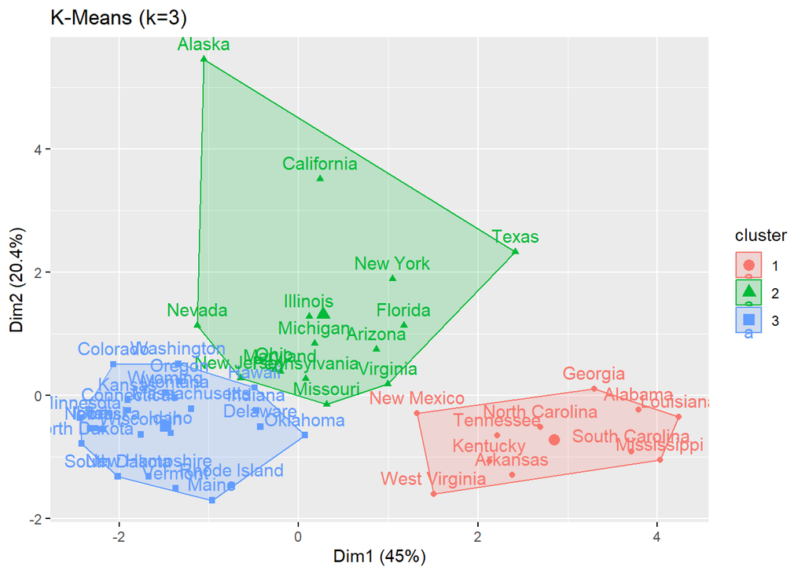

```r
# k = 3
km3 <- kmeans(scale(state.x77), centers = 3, nstart = 25)
fviz_cluster(km3, data = scale(state.x77), main = "K-Means (k=3)")
```

Diambil nilai k=3

```r
set.seed(97)
km_state <- kmeans(data_scaled, centers = 3, nstart = 25)

# Lihat hasil ringkas
km_state
```

```
## K-means clustering with 3 clusters of sizes 15, 11, 24
##
## Cluster means:
##   Population     Income   Illiteracy   Life Exp     Murder    HS Grad
## 1  0.9462026  0.7416690  0.005468667 -0.3242467  0.5676042  0.1558335
## 2 -0.2269956 -1.3014617  1.391527063 -1.1773136  1.0919809 -1.4157826
## 3 -0.4873370  0.1329601 -0.641201154  0.7422562 -0.8552439  0.5515044
##        Frost       Area
## 1 -0.1960979  0.4483198
## 2 -0.7206500 -0.2340290
## 3  0.4528591 -0.1729366
##
## Clustering vector:
##        Alabama         Alaska        Arizona       Arkansas     California
##              2              1              1              2              1
##       Colorado    Connecticut       Delaware        Florida        Georgia
##              3              3              3              1              2
##         Hawaii          Idaho       Illinois        Indiana           Iowa
##              3              3              1              3              3
##         Kansas       Kentucky      Louisiana          Maine       Maryland
##              3              2              2              3              1
##  Massachusetts       Michigan      Minnesota    Mississippi       Missouri
##              3              1              3              2              1
##        Montana       Nebraska         Nevada  New Hampshire     New Jersey
##              3              3              1              3              1
##     New Mexico       New York North Carolina   North Dakota           Ohio
##              2              1              2              3              1
##       Oklahoma         Oregon   Pennsylvania   Rhode Island South Carolina
##              3              3              1              3              2
##   South Dakota      Tennessee          Texas           Utah        Vermont
##              3              2              1              3              3
##       Virginia     Washington  West Virginia      Wisconsin        Wyoming
##              1              3              2              3              3
##
## Within cluster sum of squares by cluster:
## [1] 111.66951  23.62227  67.72742
##  (between_SS / total_SS =  48.2 %)
##
## Available components:
##
## [1] "cluster"      "centers"      "totss"        "withinss"     "tot.withinss"
## [6] "betweenss"    "size"         "iter"         "ifault"
```

Nilai 48.2% berarti hasil clustering sudah lumayan baik. Sekitar 48% variasi total data dapat dijelaskan oleh perbedaan antar cluster. Menunjukkan ada pemisahan yang cukup jelas antar kelompok, meskipun masih ada sedikit overlap antar cluster.

## Hasil Clustering

```r
table(km_state$cluster)
```

```
##
##  1  2  3
## 15 11 24
```

Banyak observasi pada tiap kluster, kluster 1 terdapat 15 observasi, kluster 2 11 observasi, dan kluster 3 24 observasi.

```r
head(data.frame(Observasi = 1:length(km_state$cluster),
           Cluster = km_state$cluster),10)
```

```
##             Observasi Cluster
## Alabama             1       2
## Alaska              2       1
## Arizona             3       1
## Arkansas            4       2
## California          5       1
## Colorado            6       3
## Connecticut         7       3
## Delaware            8       3
## Florida             9       1
## Georgia            10       2
```

Tabel data dengan penambahan kolom clusternya

```r
data_clustered <- cbind(data_state, Cluster = as.factor(km_state$cluster))
head(data_clustered)
```

```
##            Population Income Illiteracy Life Exp Murder HS Grad Frost   Area
## Alabama          3615   3624        2.1    69.05   15.1    41.3    20  50708
## Alaska            365   6315        1.5    69.31   11.3    66.7   152 566432
## Arizona          2212   4530        1.8    70.55    7.8    58.1    15 113417
## Arkansas         2110   3378        1.9    70.66   10.1    39.9    65  51945
## California      21198   5114        1.1    71.71   10.3    62.6    20 156361
## Colorado         2541   4884        0.7    72.06    6.8    63.9   166 103766
##            Cluster
## Alabama          2
## Alaska           1
## Arizona          1
## Arkansas         2
## California       1
## Colorado         3
```

Rata-rata setiap variabel di masing-masing cluster

```r
aggregate(data_state, by = list(Cluster = km_state$cluster), mean)
```

```
##   Cluster Population   Income Illiteracy Life Exp    Murder  HS Grad     Frost
## 1       1   8470.733 4891.533  1.1733333 70.44333  9.473333 54.36667  94.26667
## 2       2   3233.000 3636.091  2.0181818 69.29818 11.409091 41.67273  67.00000
## 3       3   2070.708 4517.500  0.7791667 71.87500  4.220833 57.56250 128.00000
##        Area
## 1 108989.80
## 2  50766.82
## 3  55979.67
```

# Komponen

sejumlah komponen penting untuk memahami hasil pengelompokan

```r
names(km_state)
```

```
## [1] "cluster"      "centers"      "totss"        "withinss"     "tot.withinss"
## [6] "betweenss"    "size"         "iter"         "ifault"
```

## Label cluster untuk setiap observasi

```r
km_state$cluster
```

```
##        Alabama         Alaska        Arizona       Arkansas     California
##              2              1              1              2              1
##       Colorado    Connecticut       Delaware        Florida        Georgia
##              3              3              3              1              2
##         Hawaii          Idaho       Illinois        Indiana           Iowa
##              3              3              1              3              3
##         Kansas       Kentucky      Louisiana          Maine       Maryland
##              3              2              2              3              1
##  Massachusetts       Michigan      Minnesota    Mississippi       Missouri
##              3              1              3              2              1
##        Montana       Nebraska         Nevada  New Hampshire     New Jersey
##              3              3              1              3              1
##     New Mexico       New York North Carolina   North Dakota           Ohio
##              2              1              2              3              1
##       Oklahoma         Oregon   Pennsylvania   Rhode Island South Carolina
##              3              3              1              3              2
##   South Dakota      Tennessee          Texas           Utah        Vermont
##              3              2              1              3              3
##       Virginia     Washington  West Virginia      Wisconsin        Wyoming
##              1              3              2              3              3
```

```r
km_state$cluster
```

```
##        Alabama         Alaska        Arizona       Arkansas     California
##              2              1              1              2              1
##       Colorado    Connecticut       Delaware        Florida        Georgia
##              3              3              3              1              2
##         Hawaii          Idaho       Illinois        Indiana           Iowa
##              3              3              1              3              3
##         Kansas       Kentucky      Louisiana          Maine       Maryland
##              3              2              2              3              1
##  Massachusetts       Michigan      Minnesota    Mississippi       Missouri
##              3              1              3              2              1
##        Montana       Nebraska         Nevada  New Hampshire     New Jersey
##              3              3              1              3              1
##     New Mexico       New York North Carolina   North Dakota           Ohio
##              2              1              2              3              1
##       Oklahoma         Oregon   Pennsylvania   Rhode Island South Carolina
##              3              3              1              3              2
##   South Dakota      Tennessee          Texas           Utah        Vermont
##              3              2              1              3              3
##       Virginia     Washington  West Virginia      Wisconsin        Wyoming
##              1              3              2              3              3
```

## Total variasi data (Total Sum of Squares)

```r
km_state$totss
```

```
## [1] 392
```

## Variasi dalam masing-masing cluster

```r
km_state$withinss
```

```
## [1] 111.66951  23.62227  67.72742
```

Menunjukkan bahwa ragam pada kluster 1 yang peling besar, disusul kluster 3 kemudian 2.

## Jumlah keseluruhan variasi dalam cluster

```r
km_state$tot.withinss
```

```
## [1] 203.0192
```

## Variasi antar cluster

```r
km_state$betweenss
```

```
## [1] 188.9808
```

## Jumlah anggota setiap cluster

```r
km_state$size
```

```
## [1] 15 11 24
```

## Jumlah iterasi hingga konvergen

```r
km_state$iter
```

```
## [1] 3
```

## Status hasil (0 = sukses)

```r
km_state$ifault
```

```
## [1] 0
```

# Evaluasi Clustering

```r
# Ambil hasil cluster
cluster_km <- km_state$cluster

# ---- Evaluasi Kualitas Clustering ----
dist_matrix <- dist(data_scaled, method = "euclidean")

sil <- mean(silhouette(cluster_km, dist_matrix)[, 3])
ch <- intCriteria(traj = as.matrix(data_scaled),
                  part = cluster_km,
                  crit = "Calinski_Harabasz")$calinski_harabasz
dunn <- intCriteria(traj = as.matrix(data_scaled),
                    part = cluster_km,
                    crit = "Dunn")$dunn

# Tampilkan hasil evaluasi
data.frame(Silhouette = sil,
           Calinski_Harabasz = ch,
           Dunn = dunn)
```

```
##   Silhouette Calinski_Harabasz      Dunn
## 1  0.3170473          21.87502 0.1257109
```

Nilai Silhouette menunjukkan seberapa baik setiap observasi berada dalam clusternya sendiri dibandingkan dengan cluster lain. Nilai 0.32 menunjukkan struktur cluster ada tapi tidak terlalu kuat. Masih mungkin ada tumpang tindih antar cluster atau perlu jumlah cluster lain untuk hasil yang lebih baik.

Indeks Calinski_Harabasz membandingkan variasi antar cluster (antara-cluster variance) dengan variasi dalam cluster (within-cluster variance). Semakin besar nilainya, semakin baik pemisahan antar cluster dan semakin rapat cluster-nya.

Indeks Dunn mengukur rasio antara jarak minimum antar cluster dan diameter maksimum dalam cluster. Nilai 0.13 relatif rendah, berarti ada overlap antar cluster atau beberapa cluster tidak terlalu rapat.

```r
# ---- Karakteristik Tiap Cluster ----
data_clustered <- data.frame(state.x77, cluster = factor(cluster_km))

cluster_summary <- data_clustered %>%
  group_by(cluster) %>%
  summarise(across(where(is.numeric), mean, .names = "{.col}"))

cluster_summary
```

```
## # A tibble: 3 × 9
##   cluster Population Income Illiteracy Life.Exp Murder HS.Grad Frost    Area
##   <fct>        <dbl>  <dbl>      <dbl>    <dbl>  <dbl>   <dbl> <dbl>   <dbl>
## 1 1            8471.  4892.      1.17      70.4   9.47    54.4  94.3 108990.
## 2 2            3233   3636.      2.02      69.3  11.4     41.7  67    50767.
## 3 3            2071.  4518.      0.779     71.9   4.22    57.6 128    55980.
```

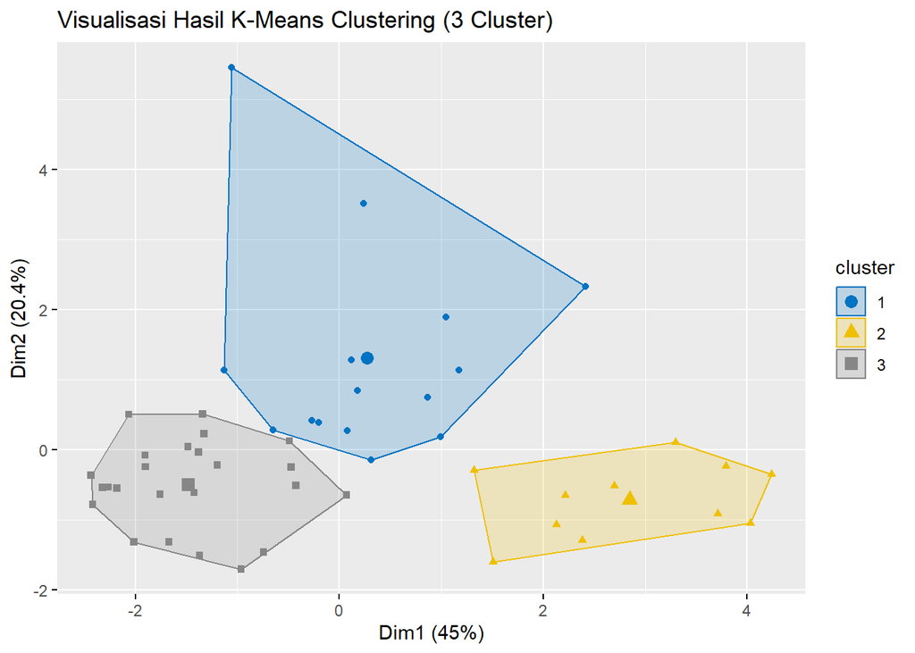

```r
fviz_cluster(km_state, data = data_scaled,
palette = "jco", geom = "point",
main = "Visualisasi Hasil K-Means Clustering (3 Cluster)")
```

```r
# ---- Ubah ke format long ----
heat_data <- cluster_summary %>%
  pivot_longer(-cluster, names_to = "Variabel", values_to = "Rata2")

# ---- Normalisasi nilai rata-rata antar variabel ----
heat_data <- heat_data %>%
  group_by(Variabel) %>%
  mutate(Rata2_Skala = rescale(Rata2, to = c(0, 1))) %>%
  ungroup()

head(heat_data)
```

```
## # A tibble: 6 × 4
##   cluster Variabel     Rata2 Rata2_Skala
##   <fct>   <chr>        <dbl>       <dbl>
## 1 1       Population 8471.         1
## 2 1       Income     4892.         1
## 3 1       Illiteracy    1.17       0.318
## 4 1       Life.Exp     70.4        0.444
## 5 1       Murder        9.47       0.731
## 6 1       HS.Grad      54.4        0.799
```

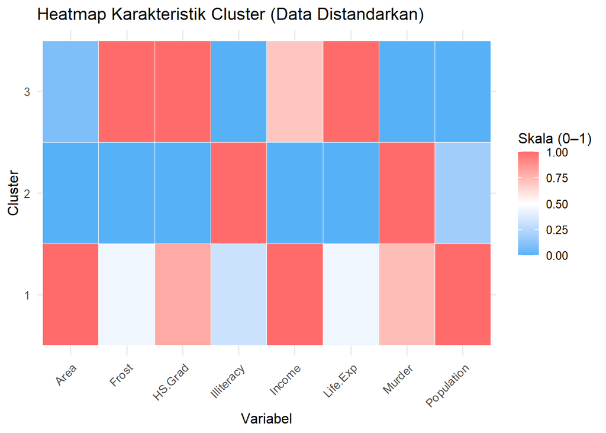

```r
# ---- Heatmap dengan data terskala ----
ggplot(heat_data, aes(x = Variabel, y = cluster, fill = Rata2_Skala)) +
  geom_tile(color = "white") +
  scale_fill_gradientn(colors = c("#56B1F7", "white", "#FF6B6B"),
                       name = "Skala (0–1)") +
  labs(title = "Heatmap Karakteristik Cluster (Data Distandarkan)",
       x = "Variabel", y = "Cluster") +
  theme_minimal(base_size = 12) +
  theme(axis.text.x = element_text(angle = 45, hjust = 1))
```

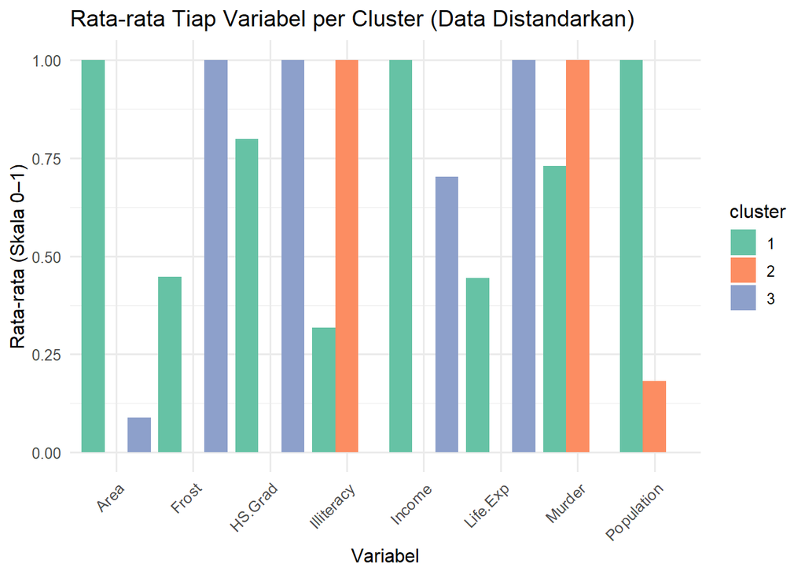

```r
# ---- Bar Plot versi terskala ----
ggplot(heat_data, aes(x = Variabel, y = Rata2_Skala, fill = cluster)) +
  geom_bar(stat = "identity", position = "dodge") +
  scale_fill_brewer(palette = "Set2") +
  labs(title = "Rata-rata Tiap Variabel per Cluster (Data Distandarkan)",
       x = "Variabel", y = "Rata-rata (Skala 0–1)") +
  theme_minimal(base_size = 12) +
  theme(axis.text.x = element_text(angle = 45, hjust = 1))
```